# Ictus y Factores_Riesgo

Andrés Estévez, Paula Martínez

2024-11-11

Link del repositorio de github [aquí](https://github.com/PaulaMartinezCamarero/Seminario_Fuentes_Datos)

```r
#antes de salir
save.image(file="objetos_actuales.Rdata")

#cuando te metes
load("OUTPUT/objetos_actuales.Rdata")
```

# Importación de librerías necesarias

```r
library(tidyjson)
library(rjson)
library(tidyverse)
```

```r
library(dplyr)
library(ggplot2)
library(lubridate)
library(readr)
```

# Introducción

En nuestro seminario vamos a estudiar las altas hospitalarias por ictus, en los diferentes hospitales de Castilla y León durante cuatro años, y como estas, están relacionadas con distintos factores de riesgo.

Durante el desarrollo de nuestro seminario vamos a trabajar con datos de dos factores de riesgo, los cuales son: la calidad del aire y valorar si los centros de desintoxicación los podemos considerar como factor de riesgo o como factor de prevención de sufrir un ictus.

# Objetivos

**Objetivos principales:**

1.Estudiar la cantidad de altas hospitalarias por ictus que hay en cada provincia de Castilla y León y ver como varían dependiendo del sexo y de la edad.

2.Analizar si a peor calidad del aire hay más riesgo de sufrir un ictus.

3.Estudiar la relación entre centros de ayuda a la desintoxicación por provincia y el número de ictus.

# Procedencia de datos

Los datos han sido recabados de [Datos abiertos del gobierno de españa](https://datos.gob.es/es/) que hasta el momento contiene cerca de 90000 conjuntos de datos, distribuidos en un amplio número de temáticas.También supera las 550000 distribuciones, Además de 313 iniciativas de datos abiertos.

# Descripción y Importación de datos

**Descripción:**

Contamos con 1 set de datos en tipo *.csv*. Este formato, **(Comma Separated Values)** son archivos de texto que en pricipio deberían estar con los caracteres separados por comas, aunque en algunos de nuestros datos se usa punto y coma en lugar de la coma.

Este es nuestro archivo *.csv*.: -[calidad_aire](https://servicios.jcyl.es/esco/cargarFrmDatosHistoricos.action)

También contamos con dos sets de datos *.json*.**(JavaScript Object Notation)** es un formato para almacenar e intercambiar datos.

Estos son nuestros archivos *.json*.: -[altas_hospitalarias_ictus](https://datos.gob.es/es/catalogo/a07002862-altas-hospitalarias-con-diagnostico-de-ictus) -[centros_servicios_saisde](https://servicios.ine.es/wstempus/jsCache/es/DATOS_TABLA/65334?tip=AM&) Este último proviene del **Instituto Nacional de Estadística (INE)**.

# Importación de datos

## Importamos los datos de las altas hospitalarias por ictus

```r
altas_hospitalarias_ictus <- fromJSON(file="INPUT/data/altas_hospitalarias_ictus.json")
```

## Importamos los datos de la calidad del aire:

```r
calidad_aire <- read_csv("INPUT/data/calidad_aire.csv")
calidad_aire
```

```
## # A tibble: 2,135 × 10
##    Fecha   `CO (mg/m3)` `NO (ug/m3)` `NO2 (ug/m3)` `O3 (ug/m3)` `PM10 (ug/m3)`
##    <chr>   <chr>               <dbl>         <dbl>        <dbl>          <dbl>
##  1 10/2019 <NA>                    2             5           52             11
##  2 10/2019 <NA>                    5            15           43             20
##  3 10/2019 0,2                     6            18           NA             17
##  4 10/2019 <NA>                    4            10           54              9
##  5 10/2019 <NA>                    2             3           56             NA
##  6 10/2019 <NA>                    6            16           NA             21
##  7 10/2019 <NA>                    5            14           46             16
##  8 10/2019 <NA>                    2            12           NA             11
##  9 10/2019 <NA>                    2             7           48             10
## 10 10/2019 <NA>                    2             5           47             11
## # ℹ 2,125 more rows
## # ℹ 4 more variables: `PM25 (ug/m3)` <dbl>, `SO2 (ug/m3)` <dbl>,
## #   Provincia <chr>, Estación <chr>
```

## Importamos los datos de los centros de desintoxicación:

```r
centros_servicios_saisde <- fromJSON(file = "INPUT/data/centros_servicios_saisde.json")
```

## Importamos la función que cuenta el número de ictus por provincia:

```r
source("INPUT/functions/ictus_por_provincia.R")
ictus_por_provincia(Provincias$Provincia)
```

```
##      Avila     Burgos       León   Palencia  Salamanca    Segovia      Soria
##       1178       2788       3513       1064       3743       1142        601
## Valladolid     Zamora
##       4575       1486
```

```r
df_ictus_por_provincia <- data.frame(provincia=datos$pob.provincia,
                n_ictus=datos$num_ictus.numero_ictus)
df_ictus_por_provincia
```

```
##    provincia n_ictus
## 1      Avila    1178
## 2     Burgos    2788
## 3       León    3513
## 4   Palencia    1064
## 5  Salamanca    3743
## 6    Segovia    1142
## 7      Soria     601
## 8 Valladolid    4575
## 9     Zamora    1486
```

# Manipulación de datos y resolución de cuestiones:

# Ictus, edad y sexo

Para resolver el primer objetivo vamos a:

- Obtener las edades de todos los pacientes para ver si la edad es un factor determinante en el aumento de los ictus, para ello necesitamos conocer como está organizado nuestro json.

```r
altas_hospitalarias_ictus %>%
  spread_all() %>%
  gather_object %>%
  json_types %>%
  count(name, type)
```

```
## # A tibble: 4 × 3
##   name             type       n
##   <chr>            <fct>  <int>
## 1 datasetid        string 20090
## 2 fields           object 20090
## 3 record_timestamp string 20090
## 4 recordid         string 20090
```

```r
altas_hospitalarias_ictus %>%
  enter_object(fields) %>%
  gather_object %>%
  spread_all %>%
  json_types%>%
  count(name, type)
```

```
## # A tibble: 11 × 3
##    name                                     type       n
##    <chr>                                    <fct>  <int>
##  1 ambito_de_procedencia                    string 20040
##  2 area                                     string 20090
##  3 dia_de_la_semana_en_la_fecha_del_alta    string 20090
##  4 dia_de_la_semana_en_la_fecha_del_ingreso string 20090
##  5 edad                                     number 20090
##  6 fecha_de_alta                            string 20090
##  7 fecha_de_ingreso                         string 20090
##  8 hospital                                 string 20090
##  9 provincia                                string 20090
## 10 sexo                                     string 20090
## 11 zona_basica_de_salud_del_paciente        string 20038
```

Dejamos la tabla entera tabulada, para trabajar a partir de ahora con este objeto:

```r
altas_hosp_ictus_tab <- altas_hospitalarias_ictus%>%
  spread_all()%>%
  enter_object("fields")%>%
  spread_all()
altas_hosp_ictus_tab
```

```
## # A tbl_json: 20,090 x 27 tibble with a "JSON" attribute
##    ..JSON document.id datasetid recordid record_timestamp fields.fecha_de_ingr…¹
##    <chr>        <int> <chr>     <chr>    <chr>            <chr>
##  1 "{\"f…           1 altas-ho… d642d9b… 2024-09-09T01:0… 2023-12-30T05:40:00+0…
##  2 "{\"f…           2 altas-ho… 1d47d7f… 2024-09-09T01:0… 2023-12-30T03:16:00+0…
##  3 "{\"f…           3 altas-ho… 95a004c… 2024-09-09T01:0… 2023-12-30T00:07:00+0…
##  4 "{\"f…           4 altas-ho… aab2391… 2024-09-09T01:0… 2023-12-29T18:29:00+0…
##  5 "{\"f…           5 altas-ho… 337420e… 2024-09-09T01:0… 2023-12-29T00:43:00+0…
##  6 "{\"f…           6 altas-ho… 32120d2… 2024-09-09T01:0… 2023-12-28T21:00:00+0…
##  7 "{\"f…           7 altas-ho… 4b61391… 2024-09-09T01:0… 2023-12-28T18:53:00+0…
##  8 "{\"f…           8 altas-ho… 9bb0dbc… 2024-09-09T01:0… 2023-12-28T15:25:00+0…
##  9 "{\"f…           9 altas-ho… 02c92ba… 2024-09-09T01:0… 2023-12-28T12:59:00+0…
## 10 "{\"f…          10 altas-ho… 3f05cd4… 2024-09-09T01:0… 2023-12-28T02:29:00+0…
## # ℹ 20,080 more rows
## # ℹ abbreviated name: ¹fields.fecha_de_ingreso
## # ℹ 21 more variables: fields.ambito_de_procedencia <chr>, fields.area <chr>,
## #   fields.zona_basica_de_salud_del_paciente <chr>, fields.provincia <chr>,
## #   fields.edad <dbl>, fields.sexo <chr>, fields.fecha_de_alta <chr>,
## #   fields.dia_de_la_semana_en_la_fecha_del_ingreso <chr>,
## #   fields.dia_de_la_semana_en_la_fecha_del_alta <chr>, …
```

Calculamos el número de personas que han sufrido un ictus para cada edad, para ello obtenemos el atributo edad de cada una de las personas.Además lo haremos de dos maneras:

```r
edades_total <- altas_hosp_ictus_tab %>%
  rename(Edad = edad) %>%
  select(Edad)
edades_total
```

```
## # A tbl_json: 20,090 x 2 tibble with a "JSON" attribute
##    ..JSON                 Edad
##    <chr>                 <dbl>
##  1 "{\"fecha_de_ingr..."    90
##  2 "{\"fecha_de_ingr..."    83
##  3 "{\"fecha_de_ingr..."    72
##  4 "{\"fecha_de_ingr..."    78
##  5 "{\"fecha_de_ingr..."    76
##  6 "{\"fecha_de_ingr..."    76
##  7 "{\"fecha_de_ingr..."    81
##  8 "{\"fecha_de_ingr..."    74
##  9 "{\"fecha_de_ingr..."    78
## 10 "{\"fecha_de_ingr..."    53
## # ℹ 20,080 more rows
```

Importamos función que cuenta el total para cada una de las edades:

### Primera manera (orientada en programación) para obtener el numero de casos por edad

Se trata de una función programada más desde un punto de vista de programación, más adelante mostraremos como hacerlo desde un enfoque en el manejo de datos como se requiere en la asignatura y por ende, la gran mayoría de código quedará implementado de la segunda manera.

```r
source("INPUT/functions/total_por_edad.R")
resultados_edad <- total_por_edad(edades_total)
print(resultados_edad)
```

```
##     Edad Conteo
## 1      1      3
## 2      2      0
## 3      3      0
## 4      4      0
## 5      5      1
## 6      6      0
## 7      7      1
## 8      8      3
## 9      9      5
## 10    10      0
## 11    11      0
## 12    12      1
## 13    13      2
## 14    14      4
```

[output cut: 90 more lines]

### Segunda manera (orientada al manejo de datos) para obtener el numero de casos por edad

```r
ictus_por_edad <- edades_total%>%
  group_by(Edad)%>%
  summarise(num_ictus=n())
ictus_por_edad
```

```
## # A tibble: 99 × 2
##     Edad num_ictus
##    <dbl>     <int>
##  1     0         7
##  2     1         3
##  3     5         1
##  4     7         1
##  5     8         3
##  6     9         5
##  7    12         1
##  8    13         2
##  9    14         4
## 10    15         2
## # ℹ 89 more rows
```

Realizamos una regresión polinómica:

```r
regresion_edad_ictus <- lm(num_ictus~poly(Edad,3),data=ictus_por_edad)
summary(regresion_edad_ictus)
```

```
##
## Call:
## lm(formula = num_ictus ~ poly(Edad, 3), data = ictus_por_edad)
##
## Residuals:
##     Min      1Q  Median      3Q     Max
## -227.10  -81.20  -21.57   79.80  279.25
##
## Coefficients:
##                Estimate Std. Error t value Pr(>|t|)
## (Intercept)      202.93      10.82  18.759  < 2e-16 ***
## poly(Edad, 3)1  1449.03     107.64  13.462  < 2e-16 ***
## poly(Edad, 3)2  -527.86     107.64  -4.904 3.87e-06 ***
## poly(Edad, 3)3 -1368.52     107.64 -12.714  < 2e-16 ***
## ---
## Signif. codes:  0 '***' 0.001 '**' 0.01 '*' 0.05 '.' 0.1 ' ' 1
##
## Residual standard error: 107.6 on 95 degrees of freedom
## Multiple R-squared:  0.7943, Adjusted R-squared:  0.7879
## F-statistic: 122.3 on 3 and 95 DF,  p-value: < 2.2e-16
```

Gráfico que explica el modelo

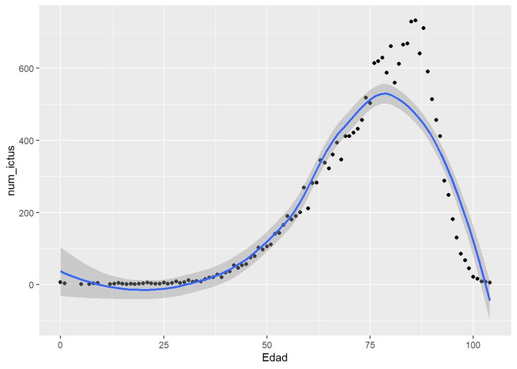

```r
ggplot(data=ictus_por_edad, aes(x=Edad,y=num_ictus))+
  geom_point()+
  geom_smooth()
```

Se ve claramente como a edades bajas el número deictus es muy reducido pero a partir de la barrera de los 45-50 empieza a subir drásticamente hasta los 75-88 que empieza a disminuir ya que a estas edades comienza a disminuir la tasa de supervivencia ya que las personas fallecen por otras patologías o por causas naturales.

- 2 Obtener el número de hombres y mujeres para ver si el sexo influye en la cantidad de ictus

Conteo por sexo:

```r
sexototal <- altas_hosp_ictus_tab %>%
  rename(Sexo = sexo) %>%
  select(Sexo)
total_sexo <- sexototal$Sexo
```

Llamamos a la función que nos cuenta el número de hombres y de mujeres que han sufrido un ictus:

### Basado en métodos de programación

```r
source("INPUT/functions/total_por_sexo.R")
resultados_sexo <- total_por_sexo(total_sexo)
print(resultados_sexo)
```

```
##     Sexo Conteo
## 1 Hombre  11124
## 2  Mujer   8966
```

### Basado en técnicas de manejo de datos

```r
ictus_por_sexo<- sexototal%>%
  group_by(Sexo)%>%
  summarise(num_ictus=n())
ictus_por_sexo
```

```
## # A tibble: 2 × 2
##   Sexo   num_ictus
##   <chr>      <int>
## 1 Hombre     11124
## 2 Mujer       8966
```

Un total de 11124 sufrieron un ictus y el número de mujeres fue de 8966.

Mostramos de manera visual con un gráfico de barras sencillo la cantidad de hombres y mujeres que han sufrido un ictus:

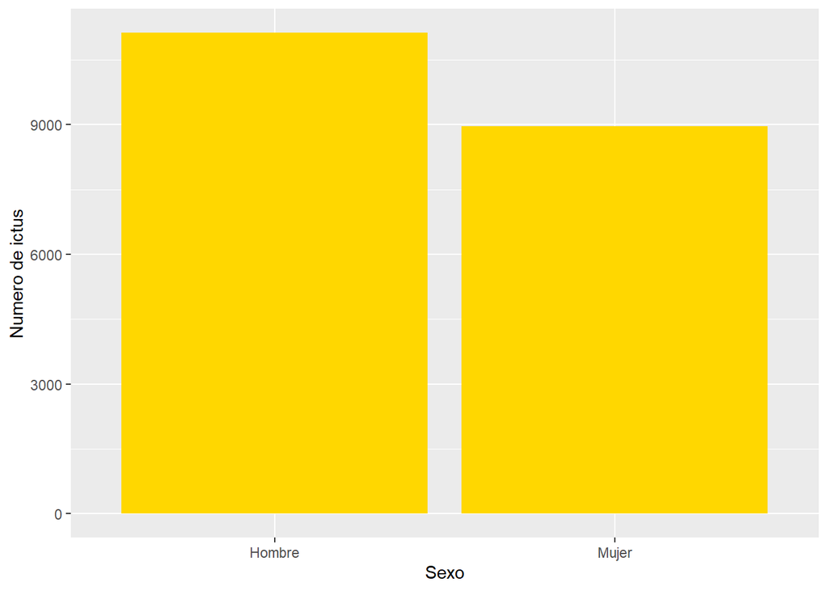

```r
ictus_por_sexo%>%
  ggplot(mapping=aes(x=Sexo, y=num_ictus))+
  geom_bar(stat="identity", fill="gold")+
  labs(x="Sexo",y="Numero de ictus")
```

Realizamos un ANOVA: Para ello necesitamos conocer la media de la edad y su desviación estandar.

```r
media_desviacion <- altas_hosp_ictus_tab %>%
  group_by(sexo) %>%
  summarise(
    media = mean(edad, na.rm = TRUE),
    desviacion_estandar = sd(edad, na.rm = TRUE)
  )

media_desviacion
```

```
## # A tibble: 2 × 3
##   sexo   media desviacion_estandar
##   <chr>  <dbl>               <dbl>
## 1 Hombre  73.3                13.0
## 2 Mujer   78.4                13.2
```

```r
anova_resultado <- aov(edades_total$Edad ~ sexototal$Sexo, data = altas_hosp_ictus_tab)

summary(anova_resultado)
```

```
##                   Df  Sum Sq Mean Sq F value Pr(>F)
## sexototal$Sexo     1  131314  131314   765.3 <2e-16 ***
## Residuals      20088 3446613     172
## ---
## Signif. codes:  0 '***' 0.001 '**' 0.01 '*' 0.05 '.' 0.1 ' ' 1
```

Análisis estadístico: Tomamos como Test Hipótesis: H0: Medias iguales –> p-valor>0.05 H1: Medias distintas –>p-valor<0.05 Tras realizar el anova(analisis de la varianza) con la edad como variable numérica y el sexo como variable categórica vemos que el p-valor es muy bajo rechazamos la H0, lo que nos indica que el sexo es un factor estadisticamente significativo para los ictus.

Obtener el número de casos por provincias para empezar a relacionarlo con los siguientes objetivos

```r
Provincias <- altas_hosp_ictus_tab%>%
  rename(Provincia=fields.provincia)%>%
  select(Provincia)
Provincias$Provincia <- ifelse(Provincias$Provincia == "Ávila", "Avila", Provincias$Provincia)
Provincias
```

```
## # A tbl_json: 20,090 x 2 tibble with a "JSON" attribute
##    ..JSON                Provincia
##    <chr>                 <chr>
##  1 "{\"fecha_de_ingr..." Avila
##  2 "{\"fecha_de_ingr..." Valladolid
##  3 "{\"fecha_de_ingr..." León
##  4 "{\"fecha_de_ingr..." Salamanca
##  5 "{\"fecha_de_ingr..." Palencia
##  6 "{\"fecha_de_ingr..." León
##  7 "{\"fecha_de_ingr..." Zamora
##  8 "{\"fecha_de_ingr..." Avila
##  9 "{\"fecha_de_ingr..." Salamanca
## 10 "{\"fecha_de_ingr..." Segovia
## # ℹ 20,080 more rows
```

Calculamos la media de los factores más destacados del aire, agrupados por fecha y provincia.

```r
media_factores_aire <-calidad_aire%>%
    rename(provincia=Provincia)%>%
    mutate(Fechas = my(Fecha))%>%
    mutate(mes= month(Fechas))%>%
    mutate(anyo= year(Fechas))%>%
    group_by(Fechas, provincia,mes,anyo)%>%
    summarise(
      NO=mean(`NO (ug/m3)`, na.rm = TRUE),
      O3=mean(`O3 (ug/m3)`, na.rm = TRUE),
      PM25=mean(`PM25 (ug/m3)`, na.rm = TRUE)

    )%>%
    arrange(Fechas)
media_factores_aire
```

```
## # A tibble: 459 × 7
## # Groups:   Fechas, provincia, mes [459]
##    Fechas     provincia    mes  anyo    NO    O3  PM25
##    <date>     <chr>      <dbl> <dbl> <dbl> <dbl> <dbl>
##  1 2019-10-01 Avila         10  2019  2     52   NaN
##  2 2019-10-01 Burgos        10  2019  4.67  49.8   4
##  3 2019-10-01 León          10  2019  2.87  44.2 NaN
##  4 2019-10-01 Palencia      10  2019  5.57  41.4   3.5
##  5 2019-10-01 Salamanca     10  2019  3     61     5
##  6 2019-10-01 Segovia       10  2019  2     57   NaN
##  7 2019-10-01 Soria         10  2019  8.5   44   NaN
##  8 2019-10-01 Valladolid    10  2019 11.5   38.9  11
##  9 2019-10-01 Zamora        10  2019  7     47   NaN
## 10 2019-11-01 Avila         11  2019  2     60   NaN
## # ℹ 449 more rows
```

Necesitamos cambiar el formato de la fecha, para así poder trabajar y agrupar datos que contienen fechas, ya que el paquete lubridate permite hacer lo que necesitamos con las fechas, en formato fecha.

```r
#para poder hacer el estudio de manera correcta de la calidad del aire
altas_hosp_ictus_fecha_bien <- altas_hosp_ictus_tab %>%
  mutate(Fecha = ymd_hms(fields.fecha_de_ingreso))%>%
  mutate(mes= month(fields.fecha_de_ingreso))%>%
  mutate(anyo = year(fields.fecha_de_ingreso))

altas_hosp_ictus_fecha_bien$provincia <- ifelse(altas_hosp_ictus_fecha_bien$provincia == "Ávila", "Avila",altas_hosp_ictus_fecha_bien$provincia)
altas_hosp_ictus_fecha_bien
```

```
## # A tbl_json: 20,090 x 30 tibble with a "JSON" attribute
##    ..JSON document.id datasetid recordid record_timestamp fields.fecha_de_ingr…¹
##    <chr>        <int> <chr>     <chr>    <chr>            <chr>
##  1 "{\"f…           1 altas-ho… d642d9b… 2024-09-09T01:0… 2023-12-30T05:40:00+0…
##  2 "{\"f…           2 altas-ho… 1d47d7f… 2024-09-09T01:0… 2023-12-30T03:16:00+0…
##  3 "{\"f…           3 altas-ho… 95a004c… 2024-09-09T01:0… 2023-12-30T00:07:00+0…
##  4 "{\"f…           4 altas-ho… aab2391… 2024-09-09T01:0… 2023-12-29T18:29:00+0…
##  5 "{\"f…           5 altas-ho… 337420e… 2024-09-09T01:0… 2023-12-29T00:43:00+0…
##  6 "{\"f…           6 altas-ho… 32120d2… 2024-09-09T01:0… 2023-12-28T21:00:00+0…
##  7 "{\"f…           7 altas-ho… 4b61391… 2024-09-09T01:0… 2023-12-28T18:53:00+0…
##  8 "{\"f…           8 altas-ho… 9bb0dbc… 2024-09-09T01:0… 2023-12-28T15:25:00+0…
##  9 "{\"f…           9 altas-ho… 02c92ba… 2024-09-09T01:0… 2023-12-28T12:59:00+0…
## 10 "{\"f…          10 altas-ho… 3f05cd4… 2024-09-09T01:0… 2023-12-28T02:29:00+0…
## # ℹ 20,080 more rows
## # ℹ abbreviated name: ¹fields.fecha_de_ingreso
## # ℹ 24 more variables: fields.ambito_de_procedencia <chr>, fields.area <chr>,
## #   fields.zona_basica_de_salud_del_paciente <chr>, fields.provincia <chr>,
## #   fields.edad <dbl>, fields.sexo <chr>, fields.fecha_de_alta <chr>,
## #   fields.dia_de_la_semana_en_la_fecha_del_ingreso <chr>,
## #   fields.dia_de_la_semana_en_la_fecha_del_alta <chr>, …
```

Juntamos ambas tablas con sus atributos comunes que nos son de interes (mes, año y provincia)

```r
aire_con_ictus <- full_join(altas_hosp_ictus_fecha_bien, media_factores_aire, by = c("mes","anyo", "provincia"))

aire_con_ictus_resumen <- aire_con_ictus%>%
  rename(ambito=fields.ambito_de_procedencia,dia_semana=fields.dia_de_la_semana_en_la_fecha_del_ingreso)%>%
  select(Fechas,mes,anyo,edad,sexo,dia_semana,provincia,NO,O3,PM25,ambito)
aire_con_ictus_resumen
```

```
## # A tibble: 20,102 × 11
##    Fechas       mes  anyo  edad sexo   dia_semana provincia     NO    O3  PM25
##    <date>     <dbl> <dbl> <dbl> <chr>  <chr>      <chr>      <dbl> <dbl> <dbl>
##  1 2023-12-01    12  2023    90 Hombre Sábado     Avila       4     38   NaN
##  2 2023-12-01    12  2023    83 Hombre Sábado     Valladolid 12.5   31    10
##  3 2023-12-01    12  2023    72 Mujer  Viernes    León        6.88  34.5   9.5
##  4 2023-12-01    12  2023    78 Hombre Viernes    Salamanca   6.67  49.5   6
##  5 2023-12-01    12  2023    76 Mujer  Jueves     Palencia    5.2   35.6   6
##  6 2023-12-01    12  2023    76 Hombre Jueves     León        6.88  34.5   9.5
##  7 2023-12-01    12  2023    81 Hombre Jueves     Zamora      9     35   NaN
##  8 2023-12-01    12  2023    74 Hombre Jueves     Avila       4     38   NaN
##  9 2023-12-01    12  2023    78 Hombre Jueves     Salamanca   6.67  49.5   6
## 10 2023-12-01    12  2023    53 Hombre Jueves     Segovia     6     42   NaN
## # ℹ 20,092 more rows
## # ℹ 1 more variable: ambito <chr>
```

Calculamos la media de cada una de las sustancias (NO, O3 y PM25) agrupadas por provincia, año y mes. Además, contamos el número de ictus que hay para cada uno de ellos.

```r
calcula_media_sustancias_por_provincia_y_meses <-aire_con_ictus_resumen %>%
  group_by(provincia, anyo, mes) %>%
  summarize(num_ictus=n(),
            avg_NO = mean(NO, na.rm = TRUE),
            avg_O3=mean(O3, na.rm = TRUE),
            avg_PM25=mean(PM25, na.rm = TRUE))
calcula_media_sustancias_por_provincia_y_meses
```

```
## # A tibble: 459 × 7
## # Groups:   provincia, anyo [45]
##    provincia  anyo   mes num_ictus avg_NO avg_O3 avg_PM25
##    <chr>     <dbl> <dbl>     <int>  <dbl>  <dbl>    <dbl>
##  1 Avila      2019    10         1      2     52      NaN
##  2 Avila      2019    11         1      2     60      NaN
##  3 Avila      2019    12         6      6     43      NaN
##  4 Avila      2020     1        24      5     46      NaN
##  5 Avila      2020     2        17      5     42      NaN
##  6 Avila      2020     3        29      3     66      NaN
##  7 Avila      2020     4        19      2     65      NaN
##  8 Avila      2020     5        20      2     69      NaN
##  9 Avila      2020     6        37      3     72      NaN
## 10 Avila      2020     7        24      2     89      NaN
## # ℹ 449 more rows
```

Estudios confirman que “Niveles más elevados de NO el día de ingreso conlleva un aumento del riesgo de mortalidad debido a ictus” El gráfico que se muestra a continuación nos sirve para ver sí cuando la concentración de NO es mayor hay un mayor número de ictus.

Grafico de dispersión del NO:

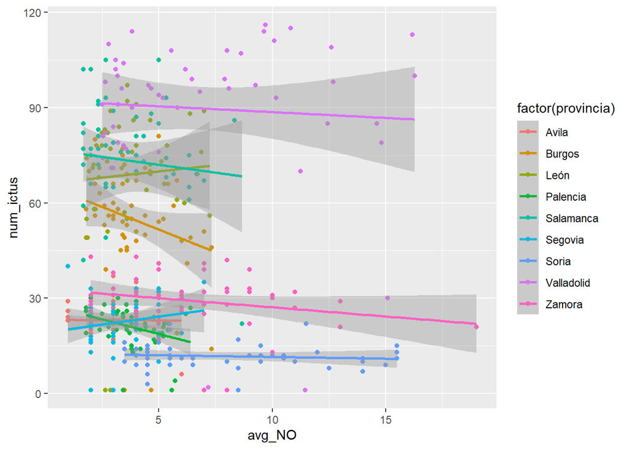

```r
calcula_media_sustancias_por_provincia_y_meses%>%
  ggplot(aes(x=avg_NO, y=num_ictus))+
  geom_point(aes(colour = factor(provincia)))+
  geom_smooth(method = "lm", aes(colour = factor(provincia)))
```

El ozono es uno de los principales contaminantes del aire. Tal y como afirma el profesor Shaowei Wu, de la universidad Xi´an Jiaotong (China): “estudios previos han sugerido que la contaminación por ozono daña el corazón y los vasos sanguíneos”.

Por ello vamos a realizar un gráfico de dispersión en el que veamos como varía el número de ictus dependiendo de como sea la media de O3 en cada provincia.

Grafico de dispersión del 03:

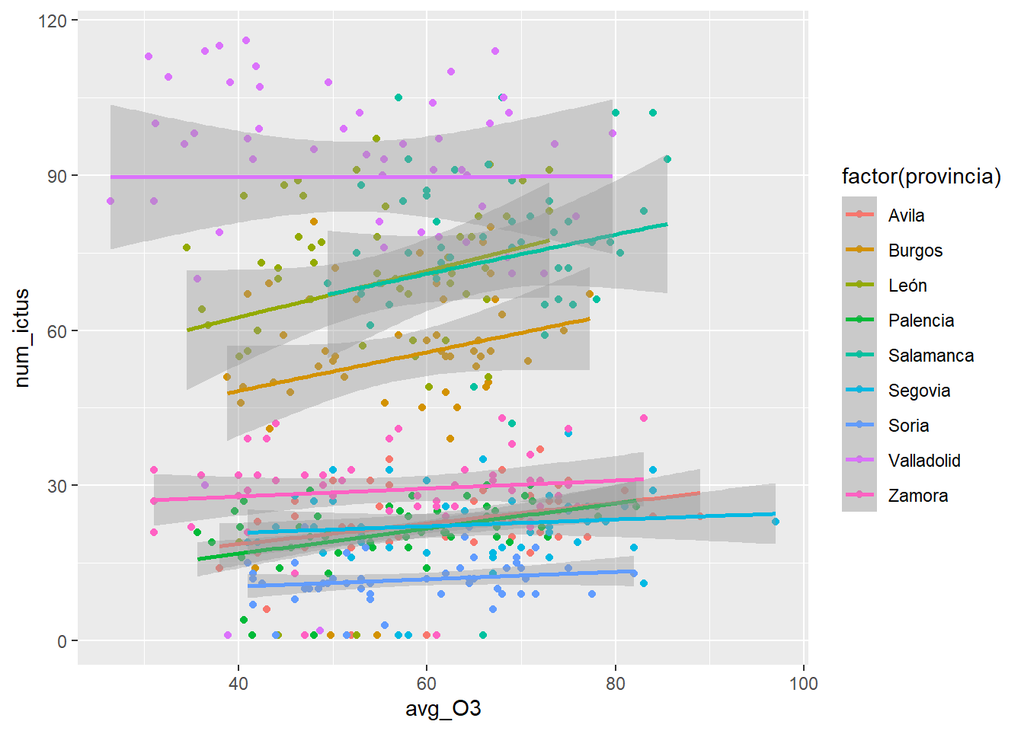

```r
calcula_media_sustancias_por_provincia_y_meses%>%
  ggplot(aes(x=avg_O3, y=num_ictus))+
  geom_point(aes(colour = factor(provincia)))+
  geom_smooth(method = "lm", aes(colour = factor(provincia)))
```

La mortalidad cardiovascular y también las hospitalización aumentan en un día determinado entre un 0,5% y un 1% por cada aumento de 10 mg/m3 de PM2.5. Por ello vamos a realizar un gráfico de dispersión para ver si cuando los niveles de PM2.5 son más elevados hay mayor número de ictus.

Grafico de dispersión del PM25:

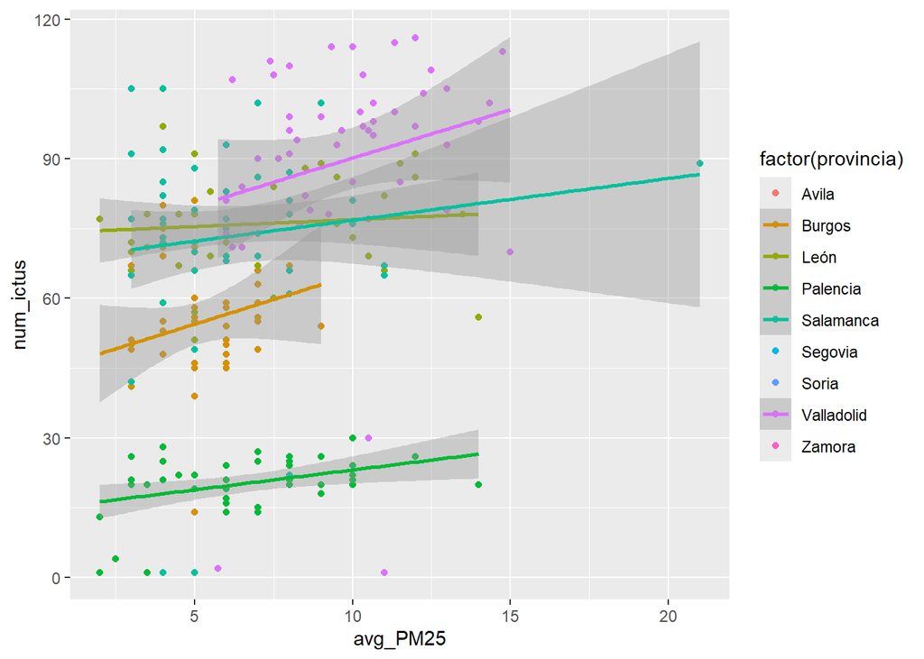

```r
calcula_media_sustancias_por_provincia_y_meses%>%
  ggplot(aes(x=avg_PM25, y=num_ictus))+
  geom_point(aes(colour = factor(provincia)))+
  geom_smooth(method = "lm", aes(colour = factor(provincia)))
```

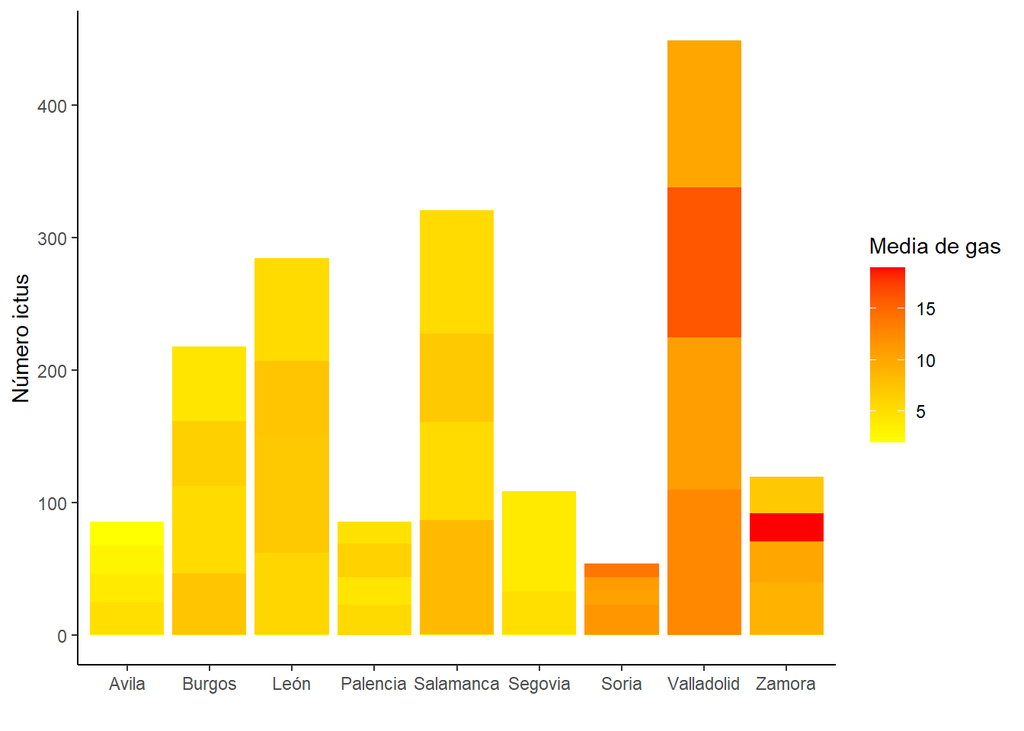

```r
calcula_media_sustancias_por_provincia_y_meses %>%
  distinct(provincia, .keep_all = TRUE) %>%
  ggplot(aes(x = reorder(provincia,anyo), y = num_ictus)) +
  geom_bar(stat = "identity", aes(fill = avg_NO)) +
  scale_fill_gradient(low = "yellow", high = "red", space = "Lab", na.value = "grey50", guide = "colourbar") +
  labs(x = "", y = "Número ictus", fill = "Media de gas") +
  theme_classic()
```

En esta gráfica aparecen representados los números de ictus por provincia y la concentración de NO, la cual aparece pintada más oscura cuando es mayor y más clara cuando es menor.

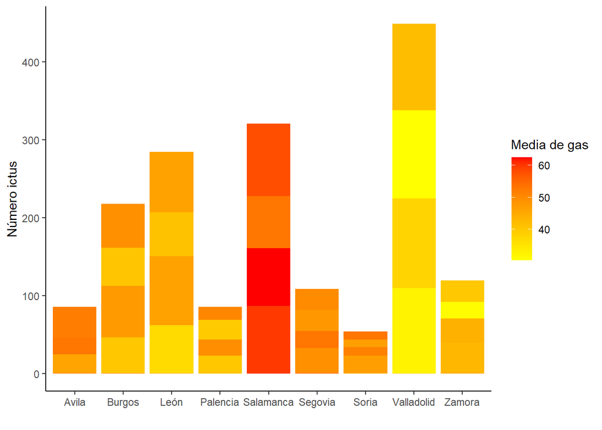

```r
calcula_media_sustancias_por_provincia_y_meses %>%
  distinct(provincia, .keep_all = TRUE) %>%
  ggplot(aes(x = reorder(provincia,anyo), y = num_ictus)) +
  geom_bar(stat = "identity", aes(fill = avg_O3)) +
  scale_fill_gradient(low = "yellow", high = "red", space = "Lab", na.value = "grey50", guide = "colourbar") +
  labs(x = "", y = "Número ictus", fill = "Media de gas") +
  theme_classic()
```

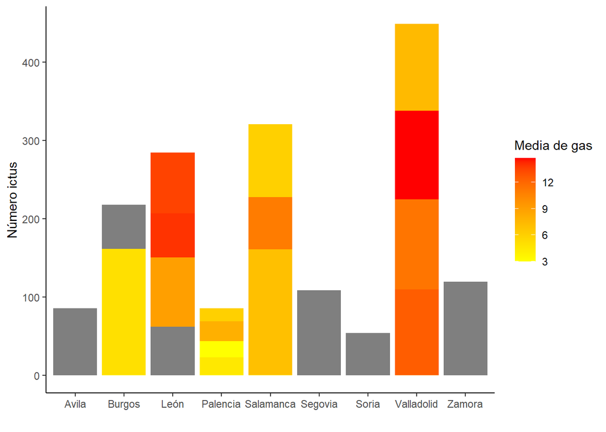

```r
calcula_media_sustancias_por_provincia_y_meses %>%
  distinct(provincia, .keep_all = TRUE) %>%
  ggplot(aes(x = reorder(provincia,anyo), y = num_ictus)) +
  geom_bar(stat = "identity", aes(fill = avg_PM25)) +
  scale_fill_gradient(low = "yellow", high = "red", space = "Lab", na.value = "grey50", guide = "colourbar") +
  labs(x = "", y = "Número ictus", fill = "Media de gas") +
  theme_classic()
```

He tenido que buscar información sobre como hacer que se puedan usar 3 columnas para una mismas provincia: https://www.geeksforgeeks.org/pivot-longer-in-r/ https://r-charts.com/es/ggplot2/facetas/ https://rpubs.com/Edimer/689875

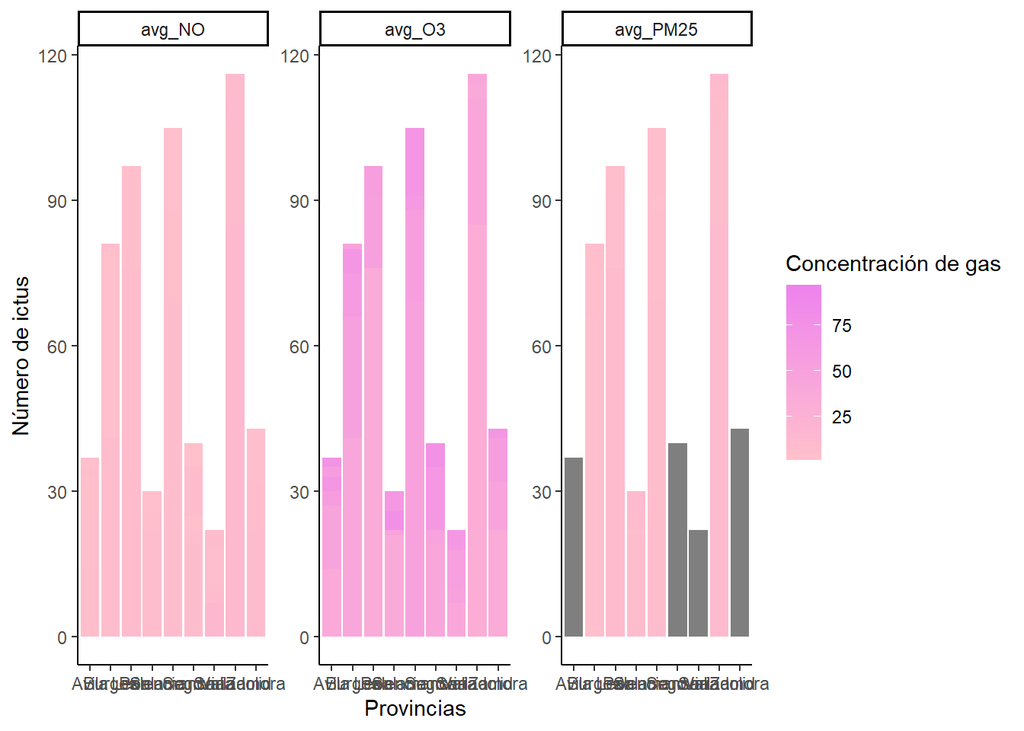

```r
aire_con_num_ictus_long <- calcula_media_sustancias_por_provincia_y_meses %>%
  distinct(provincia, num_ictus, avg_NO, avg_PM25, avg_O3) %>%
  pivot_longer(cols = c(avg_NO, avg_PM25, avg_O3),
               names_to = "gas",
               values_to = "concentracion_gas")

ggplot(aire_con_num_ictus_long,
  aes(x = provincia, y = num_ictus, fill = concentracion_gas)) +
  geom_bar(stat = "identity", position = position_dodge(width = 0.8)) + # Separar las barras
  scale_fill_gradient(low = "pink", high = "violet") +
  labs(x = "Provincias", y = "Número de ictus",fill="Concentración de gas") +
  facet_wrap(~ gas, scales = "free_y") +
  theme_classic()
```

En esta imagen, aparecen 3 gráficas, en las que se muestran el número de ictus en cada provincia y la concentración de cada gas (NO, O3 y PM25) de un color más oscuro cuando es mayor y de un color más claro cuando es menor. Resumidamente, son las tres gráficas anteriores juntadas en una para una visualización más clara.

Como dato curioso, queremos ver si el día de la semana está relacionado con los ictus

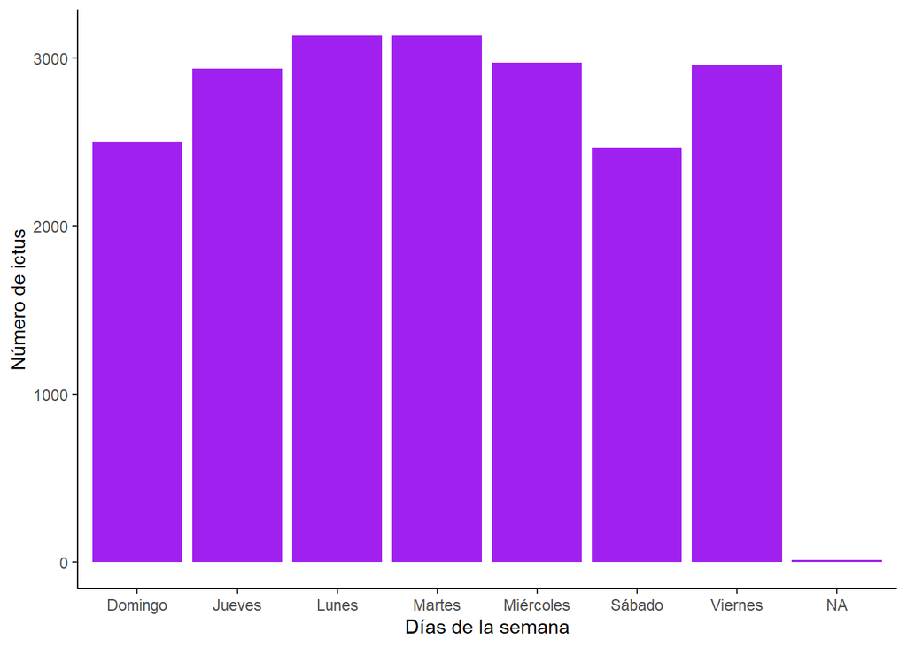

```r
numero_ictus_dia_semana <-aire_con_ictus_resumen %>%
  group_by(dia_semana) %>%
  summarize(num_ictus=n())

numero_ictus_dia_semana %>%
  ggplot(mapping=aes(x = dia_semana, y = num_ictus)) +
  geom_bar(stat = "identity", fill="purple") +
  labs(x = "Días de la semana", y="Número de ictus") +
  theme_classic()
```

#Importamos los datos de los centros de desintoxicación Visionamos los datos y vemos que con hacer un spread_all podemos obtener lo que necesitamos para nuestro trabajo.

```r
spread_all(centros_servicios_saisde)
```

```
## # A tbl_json: 99 x 22 tibble with a "JSON" attribute
##    ..JSON        document.id datasetid recordid record_timestamp fields.posicion
##    <chr>               <int> <chr>     <chr>    <chr>                      <dbl>
##  1 "{\"dataseti…           1 centros-… a42164a… 2024-04-09T16:1…              NA
##  2 "{\"dataseti…           2 centros-… 3f4b02d… 2024-04-09T16:1…              NA
##  3 "{\"dataseti…           3 centros-… 4118619… 2024-04-09T16:1…              NA
##  4 "{\"dataseti…           4 centros-… 7b8fef6… 2024-04-09T16:1…              NA
##  5 "{\"dataseti…           5 centros-… aa67d45… 2024-04-09T16:1…              NA
##  6 "{\"dataseti…           6 centros-… 536cdf6… 2024-04-09T16:1…              NA
##  7 "{\"dataseti…           7 centros-… ba153c0… 2024-04-09T16:1…              NA
##  8 "{\"dataseti…           8 centros-… 557ce5f… 2024-04-09T16:1…              NA
##  9 "{\"dataseti…           9 centros-… 96ef383… 2024-04-09T16:1…              NA
## 10 "{\"dataseti…          10 centros-… 1706963… 2024-04-09T16:1…              NA
## # ℹ 89 more rows
## # ℹ 16 more variables: fields.e_mail <chr>, fields.provincia_abreviado <chr>,
## #   fields.entidad_dependencia_institucional <chr>, fields.c_postal <chr>,
## #   fields.tipo_de_recurso <chr>, fields.telefono <chr>,
## #   fields.nivel_asistencial <chr>, fields.fax <chr>, fields.localidad <chr>,
## #   fields.longitud <dbl>, fields.direccion <chr>, fields.provincia <chr>,
## #   fields.latitud <dbl>, geometry.type <chr>, geometry.coordinates <dbl>, …
```

```r
Centros<- centros_servicios_saisde %>%
  spread_all() %>%
  count(provincia = fields.provincia)
Centros$provincia[9]="Avila"

Centros
```

```
## # A tibble: 9 × 2
##   provincia      n
##   <chr>      <int>
## 1 Burgos        12
## 2 León          18
## 3 Palencia      13
## 4 Salamanca     16
## 5 Segovia        5
## 6 Soria          4
## 7 Valladolid    17
## 8 Zamora         8
## 9 Avila          6
```

```r
ordenadas <- arrange(Centros,Centros$provincia)
ordenadas
```

```
## # A tibble: 9 × 2
##   provincia      n
##   <chr>      <int>
## 1 Avila          6
## 2 Burgos        12
## 3 León          18
## 4 Palencia      13
## 5 Salamanca     16
## 6 Segovia        5
## 7 Soria          4
## 8 Valladolid    17
## 9 Zamora         8
```

#Importamos función que imprime los habitantes de castilla y león por provincias

```r
source("INPUT/functions/poblacion_cyl.R")
poblacion_cyl
```

```
##          provincia Poblacion_total Poblacion_extranjera
## 1            Avila          159764                12868
## 2           Burgos          357370                33150
## 3             León          448573                23398
## 4         Palencia          157787                 8581
## 5        Salamanca          327089                18606
## 6          Segovia          155332                20015
## 7            Soria           89528                10363
## 8       Valladolid          521333                33352
## 9           Zamora          166927                 7601
## 10 Castilla y León         2383703               167934
##    Porc_pob_extranj_sobre_pob_total Num_munic_pob_extranj_mas_3_por_ciento
## 1                              8.05                                    106
## 2                              9.27                                    220
## 3                              5.21                                    102
## 4                              5.43                                     88
## 5                              5.68                                    130
## 6                             12.88                                    167
## 7                             11.57                                     83
## 8                              6.39                                    150
## 9                              4.55                                    110
## 10                             7.04                                   1156
```

```r
str(poblacion_cyl)
```

```
## 'data.frame':    10 obs. of  5 variables:
##  $ provincia                             : chr  "Avila" "Burgos" "León" "Palencia" ...
##  $ Poblacion_total                       : num  159764 357370 448573 157787 327089 ...
##  $ Poblacion_extranjera                  : num  12868 33150 23398 8581 18606 ...
##  $ Porc_pob_extranj_sobre_pob_total      : num  8.05 9.27 5.21 5.43 5.68 ...
##  $ Num_munic_pob_extranj_mas_3_por_ciento: num  106 220 102 88 130 ...
```

Para tener una referencia entre los centros de desintoxicación por provincia con el número de habitantes de esa provincia calcularemos cuál es el número de habitantes por centro; con el obetivo de ver realmente si hay más ictus en aquellas provincias donde el número de habitantes por centro es menor y el consumo de drogas es un factor significativo en los ictus o por el contrario no lo es.

```r
pob_centros <- full_join(poblacion_cyl,ordenadas)
tabla <- pob_centros%>%
  select(provincia,Poblacion_total,n)
source("INPUT/functions/divide.R")
hab_centro <- divide(tabla$Poblacion_total,tabla$n)
#faltaria indicar que con que provincia se corresponden esos datos.
tabla$hab_centro <- hab_centro
resultado <- tabla %>%
  select(provincia, hab_centro)
print(resultado)
```

```
##          provincia hab_centro
## 1            Avila   26627.33
## 2           Burgos   29780.83
## 3             León   24920.72
## 4         Palencia   12137.46
## 5        Salamanca   20443.06
## 6          Segovia   31066.40
## 7            Soria   22382.00
## 8       Valladolid   30666.65
## 9           Zamora   20865.88
## 10 Castilla y León         NA
```

Lo lógico es esperar que en las provincias que cuentan con un menor número de habitantes, haya menor número de ictus y menor número de centros de desintoxicación.

```r
numero_ictus <- ictus_por_provincia(Provincias)
df <- as.data.frame(numero_ictus)
df$prov <-c("Avila","Burgos","León","Palencia","Salamanca","Segovia","Soria","Valladolid","Zamora")


pob_prov_y_total <- poblacion_cyl%>%
  select(provincia, Poblacion_total)
pob_prov_y_total
```

```
##          provincia Poblacion_total
## 1            Avila          159764
## 2           Burgos          357370
## 3             León          448573
## 4         Palencia          157787
## 5        Salamanca          327089
## 6          Segovia          155332
## 7            Soria           89528
## 8       Valladolid          521333
## 9           Zamora          166927
## 10 Castilla y León         2383703
```

```r
pob_cyl_sin_ult_fila <- pob_prov_y_total [1:9,]
pob_cyl_sin_ult_fila
```

```
##    provincia Poblacion_total
## 1      Avila          159764
## 2     Burgos          357370
## 3       León          448573
## 4   Palencia          157787
## 5  Salamanca          327089
## 6    Segovia          155332
## 7      Soria           89528
## 8 Valladolid          521333
## 9     Zamora          166927
```

```r
arrange(.data=ordenadas,(ordenadas$provincia))
```

```
## # A tibble: 9 × 2
##   provincia      n
##   <chr>      <int>
## 1 Avila          6
## 2 Burgos        12
## 3 León          18
## 4 Palencia      13
## 5 Salamanca     16
## 6 Segovia        5
## 7 Soria          4
## 8 Valladolid    17
## 9 Zamora         8
```

```r
datos <- data.frame(pob=pob_cyl_sin_ult_fila,
                    centros= arrange(.data=ordenadas,(ordenadas$provincia)),
                    num_ictus=df)
str(datos)
```

```
## 'data.frame':    9 obs. of  6 variables:
##  $ pob.provincia         : chr  "Avila" "Burgos" "León" "Palencia" ...
##  $ pob.Poblacion_total   : num  159764 357370 448573 157787 327089 ...
##  $ centros.provincia     : chr  "Avila" "Burgos" "León" "Palencia" ...
##  $ centros.n             : int  6 12 18 13 16 5 4 17 8
##  $ num_ictus.numero_ictus: num  1178 2788 3513 1064 3743 ...
##  $ num_ictus.prov        : chr  "Avila" "Burgos" "León" "Palencia" ...
```

```r
datos
```

```
##   pob.provincia pob.Poblacion_total centros.provincia centros.n
## 1         Avila              159764             Avila         6
## 2        Burgos              357370            Burgos        12
## 3          León              448573              León        18
## 4      Palencia              157787          Palencia        13
## 5     Salamanca              327089         Salamanca        16
## 6       Segovia              155332           Segovia         5
## 7         Soria               89528             Soria         4
## 8    Valladolid              521333        Valladolid        17
## 9        Zamora              166927            Zamora         8
##   num_ictus.numero_ictus num_ictus.prov
## 1                   1178          Avila
## 2                   2788         Burgos
## 3                   3513           León
## 4                   1064       Palencia
## 5                   3743      Salamanca
## 6                   1142        Segovia
## 7                    601          Soria
## 8                   4575     Valladolid
## 9                   1486         Zamora
```

Gráfica de barras en la que se representa el número de ictus en cada provincia, coloreando de un color más fuerte las barras con los más centros de desintoxicación.

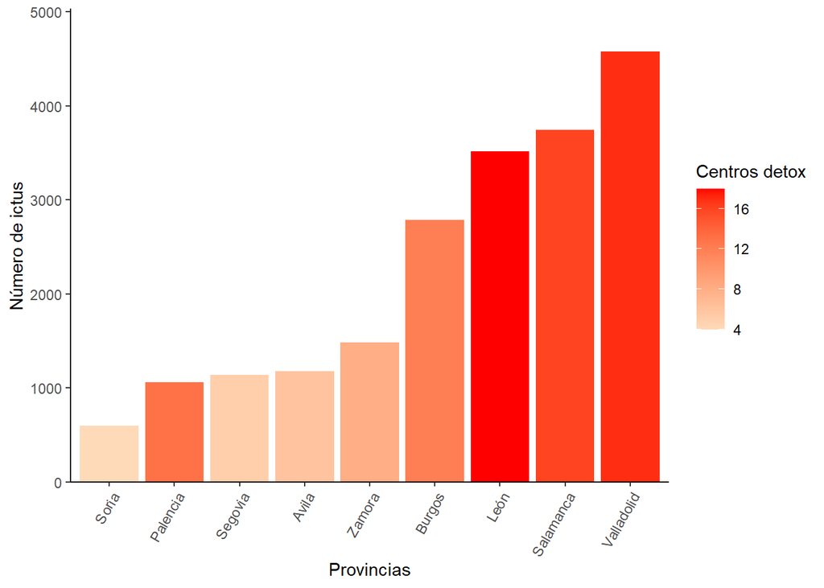

```r
datos %>%
  ggplot(mapping = aes(x = reorder(pob.provincia, num_ictus.numero_ictus), y = num_ictus.numero_ictus)) +
  geom_bar(stat = "identity", aes(fill = centros.n)) +
  scale_fill_gradient(low = "peachpuff", high = "red", space = "Lab", na.value = "grey50", guide = "colourbar") +
  labs(x = "Provincias", y = "Número de ictus", fill = "Centros detox") +
  scale_y_continuous(expand = expansion(mult = c(0, .1))) +
  theme_classic() +
  theme(axis.text.x = element_text(angle = 60, vjust = 1, hjust = 1))
```

Gráfica en la que aparece representado el número de centros por provincia:

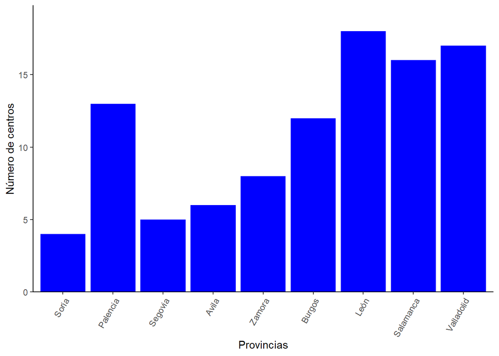

```r
datos%>%
   ggplot(mapping = aes(x = reorder(pob.provincia, num_ictus.numero_ictus), y = centros.n)) +
  geom_bar(stat = "identity",fill="blue") +
  labs(x = "Provincias", y = "Número de centros") +
  scale_y_continuous(expand = expansion(mult = c(0, .1))) +
  theme_classic() +
  theme(axis.text.x = element_text(angle = 60, vjust = 1, hjust = 1))
```

Gráfica en la que representamos el número de habitantes por centro para cada provincia:

```r
resultado
```

```
##          provincia hab_centro
## 1            Avila   26627.33
## 2           Burgos   29780.83
## 3             León   24920.72
## 4         Palencia   12137.46
## 5        Salamanca   20443.06
## 6          Segovia   31066.40
## 7            Soria   22382.00
## 8       Valladolid   30666.65
## 9           Zamora   20865.88
## 10 Castilla y León         NA
```

```r
resultado_sin_ult_fila=resultado[1:9,]
str(resultado_sin_ult_fila)
```

```
## 'data.frame':    9 obs. of  2 variables:
##  $ provincia : chr  "Avila" "Burgos" "León" "Palencia" ...
##  $ hab_centro: num  26627 29781 24921 12137 20443 ...
```

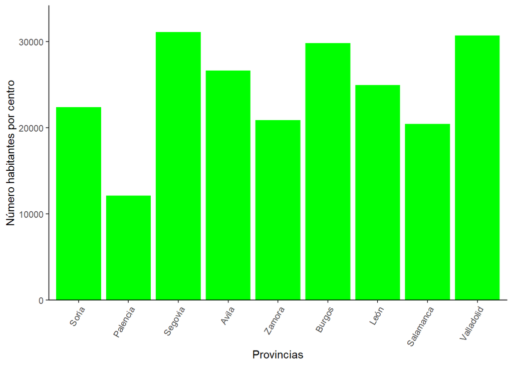

```r
ggplot(mapping = aes(x = reorder(datos$pob.provincia, datos$num_ictus.numero_ictus), y = resultado_sin_ult_fila$hab_centro)) +
  geom_bar(stat = "identity", fill = "green") +
  labs(x = "Provincias", y = "Número habitantes por centro") +
  scale_y_continuous(expand = expansion(mult = c(0, .1))) +
  theme_classic() +
  theme(axis.text.x = element_text(angle = 60, vjust = 1, hjust = 1))
```

Obtenemos una tabla que nos permite visualizar de manera numérica toda la información estudiada anteriormente:

```r
tabla_centros <- tibble(Provincia=datos$pob.provincia,
                        Numero_de_ictus=datos$num_ictus.numero_ictus,
                        Poblacion_total_cyl=pob_cyl_sin_ult_fila$Poblacion_total,
                        Numero_centros=datos$centros.n,
                        Habitantes_por_centro=resultado_sin_ult_fila$hab_centro,
                        Porcentaje_ictus_por_hab=(Numero_de_ictus/Poblacion_total_cyl)*100)
tabla_centros
```

```
## # A tibble: 9 × 6
##   Provincia  Numero_de_ictus Poblacion_total_cyl Numero_centros
##   <chr>                <dbl>               <dbl>          <int>
## 1 Avila                 1178              159764              6
## 2 Burgos                2788              357370             12
## 3 León                  3513              448573             18
## 4 Palencia              1064              157787             13
## 5 Salamanca             3743              327089             16
## 6 Segovia               1142              155332              5
## 7 Soria                  601               89528              4
## 8 Valladolid            4575              521333             17
## 9 Zamora                1486              166927              8
## # ℹ 2 more variables: Habitantes_por_centro <dbl>,
## #   Porcentaje_ictus_por_hab <dbl>
```

Por lo tanto,visualmente y falta de un estudio estadístico preciso no podemos determinar si el número de centros es un factor estadísticamente significativo para el riesgo de padecer un ictus.